# Urban Columbidae Communities

```r
library(dplyr)
library(purrr)
library(tidyverse)
library(tidyr)


library(phytools)
library(picante)
library(abdiv)
library(vegan)
library(fundiversity)
```

# Introduction

## Are urban columbidae communities strutured by habitat filtering or via competitive interactions?

- With competitive interactions we expect the phylogenetic and functional distance between species to higher than expected than within a random community.
- With habitat filtering we expect the phylogentic and functional distance between species to be lower than expected than within a random community. (Swenson et al. 2007; Cavender-Bares et al. 2009).

## Recommended community metrics (Trisos et al. 2014)

- Functional diversity of all traits (Petchey and Gaston 2002)
- Convex Hull Volume (CHV) of all traits (a multivariate measure of the range of community values) (Cornwell et al. 2006)
- Mean taxon distance (MPD) is mean pairwise phylogenetic distances between co-occurring species and is most sensitive to tree-wide patterns of phylogenetic clustering and evenness.
- Mean nearest taxon distance (MNTD) is mean pairwise phylogenetic distances separating each species from its closest co-occurring relative and is most sensitive to phylogenetic clustering or evenness at the tips of phylogeny.
- FD of each trait individually
- Variance of each trait within community previously used to measure trait clustering
- SDNDr (standard deviation of distances between neighbouring species along a single trait axis, divided by the trait range of the community) is used to detect the regular spacing in species trait values predicted by competitive exclusion.

## Recommended traits (Trisos et al. 2014)

- Overall body size.
- Trophic - beak shape (beak length, width, depth) - measures competitive exclusion (e.g. over-dispersion) via accentuation of foraging differences
- Locomotory (wing, tail, tarsus length)

## Recommended null model (Milar et al. 2017)

Many metrics sensitive to species richness. Urban communities are governed by the surrounding regional pool. For each urban community, we can generate all of the possible communities with the same species richness as the urban community with species from the regional pool. The average of all possible communities gives us a null model.

# Community data

We used all cities with a population of 250,000 or more, and that have at least 167 complete checklists that are more than 5 and less than 240 minutes in length and cover no more than 10km. We then included any Columbidae species in the urban community that appeared on at least 5% of all of these checklists recorded within the city.

This criteria comes from choosing all cities with at least 1000 checklists, and then testing 1000 times how many checklists are required to find all those species that appear on at least 5% of the total checklists. 269 cities were included in this test, and 167 was the maximum number of checklists required to find all min-5% species (which was in Auckland).

## Read in data exported from bigquery

```yaml
models:
  - name: all_columbidae_communities
    description: Regional and urban communities for all cities with a population of at least 250,000 from GHSL Data Package 2019 (Pesaresi et al. 2019), which contain at leasts 167 eBird checklists, and have at least one Columbidae species within their regional pools.
    columns:
      - name: city_id
        description: Vector ID from GHSL Data Package 2019 (Pesaresi et al. 2019)
      - name: city_name
        description: City name from Vector from GHSL Data Package 2019 (Pesaresi et al. 2019)
      - name: jetz_scientific_name
        description: The mapped name of each species whose distribution from BirdLife International’s species distribution maps (BirdLife International and Handbook of the Birds of the World 2020), overlaps with the city vector from GHSL Data Package 2019 (Pesaresi et al. 2019). Species mapped from eBird and Birdlife to JETZ taxonomy using birdlife alternative names and Avibase (Lepage 2011).
      - name: present_in_city
        description: True if the species is present on at least 5% of all valid checklists within the city
```

[output not shown]

```r
all_columbidae_communities = read_csv('bigquery_export__columbidae_jetz_urban_locations.csv')
head(all_columbidae_communities)
```

| city_id | city_name | jetz_scientific_name | present_in_city |
| --- | --- | --- | --- |
| 1 | Honolulu | Stigmatopelia_chinensis | FALSE |
| 514 | Cali | Columbina_passerina | FALSE |
| 514 | Cali | Columbina_talpacoti | TRUE |
| 514 | Cali | Geotrygon_montana | FALSE |
| 514 | Cali | Claravis_mondetoura | FALSE |
| 514 | Cali | Leptotila_plumbeiceps | FALSE |

# Site Selection

Our site metrics all compare species within communities, therefore we must have more than one species in each urban community for our analysis. Our null model requires us to create a range of dissimilar communities with the same richness as the actual urban community using species from the regional pool, therefore we must have less than the number of species in our regional pool in our urban pool.

Here we exclude then two sets of urban communities that are interesting in their own right, (1) those with 1 or less species, and (2) those with all the species from the regional pool

```r
urban_communities_tmp = all_columbidae_communities %>% group_by(city_id, city_name) %>% summarise(regional_pool_size = n(), urban_pool_size = sum(present_in_city))
head(urban_communities_tmp)
```

| city_id | city_name | regional_pool_size | urban_pool_size |
| --- | --- | --- | --- |
| 1 | Honolulu | 1 | 0 |
| 8 | Oxnard | 3 | 2 |
| 10 | San Jose | 3 | 1 |
| 19 | Concord | 2 | 1 |
| 20 | Ensenada | 3 | 0 |
| 21 | Tijuana | 4 | 1 |

Communities with 1 or less pigeon species

```r
urban_communities_tmp[urban_communities_tmp$urban_pool_size < 2,]
```

| city_id | city_name | regional_pool_size | urban_pool_size |
| --- | --- | --- | --- |
| 1 | Honolulu | 1 | 0 |
| 10 | San Jose | 3 | 1 |
| 19 | Concord | 2 | 1 |
| 20 | Ensenada | 3 | 0 |
| 21 | Tijuana | 4 | 1 |
| 26 | Antioch | 2 | 1 |
| 29 | Bakersfield | 3 | 1 |
| 32 | Palmdale | 3 | 1 |
| 34 | Stockton | 2 | 1 |
| 35 | Modesto | 2 | 1 |

[output cut: 186 more lines]

Communities with all regional species

```r
urban_communities_tmp[urban_communities_tmp$urban_pool_size == urban_communities_tmp$regional_pool_size,]
```

| city_id | city_name | regional_pool_size | urban_pool_size |
| --- | --- | --- | --- |
| 73 | Culiacán | 6 | 6 |
| 111 | Chihuahua | 3 | 3 |
| 172 | Boise | 1 | 1 |
| 192 | Provo | 1 | 1 |
| 193 | Salt Lake City | 1 | 1 |
| 207 | Ogden | 1 | 1 |
| 241 | Spokane | 1 | 1 |
| 266 | Colorado Springs | 1 | 1 |
| 273 | Denver | 1 | 1 |
| 351 | Oklahoma City | 1 | 1 |

[output cut: 53 more lines]

```yaml
models:
  - name: selected_urban_communities
    description: Sites that we will analyse that have more than 1 species, and less species than the entire regional pool
    columns:
      - name: city_id
        description: Vector ID from GHSL Data Package 2019 (Pesaresi et al. 2019)
      - name: city_name
        description: City name from Vector from GHSL Data Package 2019 (Pesaresi et al. 2019)
      - name: regional_pool_size
        description: the number of columbidae species in the city regional pool, e.g. number of species where the city vector overlaps the birdlife distribution vector
      - name: urban_pool_size
        description: the number of columbidae species that occur inside the city, e.g. the number of columbidae species that appear on at least 5% of all valid checklists within the city vector.
```

[output not shown]

Selected sites:

```r
selected_urban_communities = urban_communities_tmp[urban_communities_tmp$urban_pool_size > 1 & urban_communities_tmp$urban_pool_size != urban_communities_tmp$regional_pool_size,]
nrow(selected_urban_communities)
```

```
[1] 307
```

```r
head(selected_urban_communities)
```

| city_id | city_name | regional_pool_size | urban_pool_size |
| --- | --- | --- | --- |
| 8 | Oxnard | 3 | 2 |
| 56 | Indio | 4 | 2 |
| 65 | Hermosillo | 5 | 3 |
| 74 | Las Vegas | 5 | 2 |
| 75 | Mazatlán | 8 | 4 |
| 79 | Phoenix | 5 | 3 |

And therefore

```r
selected_columbidae_communities = all_columbidae_communities[all_columbidae_communities$city_id %in% selected_urban_communities$city_id,]
head(selected_columbidae_communities)
```

| city_id | city_name | jetz_scientific_name | present_in_city |
| --- | --- | --- | --- |
| 514 | Cali | Columbina_passerina | FALSE |
| 514 | Cali | Columbina_talpacoti | TRUE |
| 514 | Cali | Geotrygon_montana | FALSE |
| 514 | Cali | Claravis_mondetoura | FALSE |
| 514 | Cali | Leptotila_plumbeiceps | FALSE |
| 514 | Cali | Leptotila_verreauxi | FALSE |

# Trait Data

```yaml
models:
  - name: avonet_birdlife
    description: Functional traits taken from Avonet (Tobias et al. 2022) which includes core morphologic measurements, along with habitat preference
    columns:
      - name: species_name
        description: The birdlife species name
      - name: beak_length
        description: measured from tip to skull along the culmen
      - name: beak_width
        description:
      - name: beak_depth
        description:
      - name: tail_length
        description:
      - name: wing_length
        description: carpal joint to wingtip measured on the unflattened wing
      - name: tarsus_length
        description:
      - name: habitat
        description: habitat preference; one of: forest, grassland, human modified, rock, shrubland, woodland, desert
      - name: habitat_density
        description: habitat density preference (1 open to 3 dense)
      - name: trophic_niche
        description: frugivore, granivore, omnivore
      - name: primary_lifestyle
        description: generalist, insessorial, terrestrial
      - name: range_size
        description: extracted range size (km2) from Birdlife
      - name: mass
        description: body mass (grams)
```

[output not shown]

```r
avonet_birdlife_input_tmp = read_csv('avonet_birdlife.csv')
avonet_birdlife = avonet_birdlife_input_tmp[,c('Species1', 'Beak.Length_Culmen', 'Beak.Width', 'Beak.Depth', 'Tail.Length', 'Wing.Length', 'Tarsus.Length', 'Habitat', 'Habitat.Density', 'Trophic.Niche', 'Primary.Lifestyle', 'Range.Size', 'Mass')]
names(avonet_birdlife) = c('species_name', 'beak_length', 'beak_width', 'beak_depth', 'tail_length', 'wing_length', 'tarsus_length', 'habitat', 'habitat_density', 'trophic_niche', 'primary_lifestyle', 'range_size', 'mass')
head(avonet_birdlife)
```

| species_name | beak_length | beak_width | beak_depth | tail_length | wing_length | tarsus_length | habitat | habitat_density | trophic_niche | primary_lifestyle | range_size | mass |
| --- | --- | --- | --- | --- | --- | --- | --- | --- | --- | --- | --- | --- |
| Alectroenas madagascariensis | 17.5 | 4.1 | 4.2 | 81.5 | 171.0 | 22.3 | Forest | 2 | Frugivore | Insessorial | 311714.72 | 173.0 |
| Alectroenas pulcherrimus | 20.6 | 4.5 | 4.8 | 81.2 | 160.4 | 25.5 | Forest | 2 | Frugivore | Insessorial | 243.54 | 165.0 |
| Alectroenas sganzini | 19.3 | 4.4 | 4.3 | 93.0 | 164.2 | 25.3 | Forest | 2 | Frugivore | Insessorial | 2217.00 | 158.0 |
| Alopecoenas beccarii | 15.6 | 2.1 | 2.8 | 55.5 | 103.0 | 27.5 | Forest | 1 | Omnivore | Terrestrial | 167246.95 | 78.7 |
| Alopecoenas canifrons | 20.6 | 2.8 | 3.7 | 63.0 | 113.0 | 30.9 | Forest | 1 | Granivore | Terrestrial | 454.47 | 135.0 |
| Alopecoenas erythropterus | 20.7 | 3.6 | 4.3 | 73.5 | 140.5 | 31.6 | Woodland | 1 | Granivore | Terrestrial | 47.85 | 113.2 |

## Mapping trait data to JETZ taxonomy

```yaml
models:
  - name: birdlife_to_jetz_mapping
    description: Mapping from birdlife to jetz taxonomies
    columns:
      - name: species_name
        description: The birdlife species name
      - name: jetz_scientific_name
        description: The Jetz species name
```

[output not shown]

```r
birdlife_to_jetz_mapping = read_csv('bigquery_export__columbidae_taxonomic_mapping.csv')
head(birdlife_to_jetz_mapping)
```

| species_name | jetz_scientific_name |
| --- | --- |
| Treron olax | Treron_olax |
| Turtur afer | Turtur_afer |
| Ducula aenea | Ducula_aenea |
| Ducula cuprea | Ducula_badia |
| Ducula badia | Ducula_badia |
| Ducula pinon | Ducula_pinon |

Drop species in taxonomy mapping that are not in our communities - to avoid worrying about species not in our datasets

```r
paste("Species not in dataset", nrow(birdlife_to_jetz_mapping[!birdlife_to_jetz_mapping$jetz_scientific_name %in% selected_columbidae_communities$jetz_scientific_name,]))
```

```
[1] "Species not in dataset 47"
```

```r
paste("Total mapped species", nrow(birdlife_to_jetz_mapping))
```

```
[1] "Total mapped species 212"
```

```r
birdlife_to_jetz_mapping = birdlife_to_jetz_mapping[birdlife_to_jetz_mapping$jetz_scientific_name %in% selected_columbidae_communities$jetz_scientific_name,]

paste("Remaining species after removal", nrow(birdlife_to_jetz_mapping))
```

```
[1] "Remaining species after removal 165"
```

Check that we have AVONET data for all species - expect empty set

```r
birdlife_to_jetz_mapping[!birdlife_to_jetz_mapping$species_name %in% avonet_birdlife$species_name,]
```

| species_name | jetz_scientific_name |
| --- | --- |

Check that we have mapping entry for all community species - expect empty set

```r
selected_columbidae_communities[!selected_columbidae_communities$jetz_scientific_name %in% birdlife_to_jetz_mapping$jetz_scientific_name,]
```

| city_id | city_name | jetz_scientific_name | present_in_city |
| --- | --- | --- | --- |

When we map, how many duplicates do we have, and how dissimilar are they?

```r
avonet_birdlife_mapped_to_jetz_tmp = left_join(birdlife_to_jetz_mapping, avonet_birdlife)
duplicated_jetz_species_in_avonet = avonet_birdlife_mapped_to_jetz_tmp$jetz_scientific_name[duplicated(avonet_birdlife_mapped_to_jetz_tmp$jetz_scientific_name)]
avonet_birdlife_mapped_to_jetz_tmp[avonet_birdlife_mapped_to_jetz_tmp$jetz_scientific_name %in% duplicated_jetz_species_in_avonet,] %>% arrange(jetz_scientific_name)
```

| species_name | jetz_scientific_name | beak_length | beak_width | beak_depth | tail_length | wing_length | tarsus_length | habitat | habitat_density | trophic_niche | primary_lifestyle | range_size | mass |
| --- | --- | --- | --- | --- | --- | --- | --- | --- | --- | --- | --- | --- | --- |
| Chalcophaps indica | Chalcophaps_indica | 20.9 | 3.1 | 4.2 | 83.9 | 143.9 | 25.8 | Forest | 1 | Omnivore | Generalist | 4704607.55 | 136.5 |
| Chalcophaps longirostris | Chalcophaps_indica | 22.7 | 2.8 | 4.0 | 87.0 | 152.0 | 25.9 | Forest | 1 | Omnivore | Generalist | 639179.72 | 136.5 |
| Ducula cuprea | Ducula_badia | 24.7 | 8.0 | 7.2 | 156.5 | 227.9 | 26.2 | Forest | 2 | Frugivore | Insessorial | 75660.33 | 486.0 |
| Ducula badia | Ducula_badia | 27.4 | 6.7 | 5.8 | 170.8 | 232.2 | 29.3 | Forest | 2 | Frugivore | Insessorial | 2976050.68 | 486.0 |
| Geotrygon caniceps | Geotrygon_caniceps | 21.4 | 3.0 | 4.6 | 89.4 | 148.6 | 35.2 | Forest | 1 | Omnivore | Terrestrial | 23265.89 | 192.0 |
| Geotrygon leucometopia | Geotrygon_caniceps | 20.2 | 2.8 | 3.9 | 81.0 | 151.5 | 34.3 | Forest | 1 | Omnivore | Terrestrial | 4828.19 | 192.0 |
| Patagioenas albilinea | Patagioenas_fasciata | 25.8 | 4.1 | 5.7 | 141.5 | 204.9 | 26.8 | Forest | 2 | Granivore | Terrestrial | 1071014.98 | 366.3 |
| Patagioenas fasciata | Patagioenas_fasciata | 24.9 | 7.5 | 6.6 | 141.5 | 206.9 | 25.9 | Forest | 2 | Granivore | Terrestrial | 2624630.54 | 366.3 |
| Patagioenas albipennis | Patagioenas_maculosa | 24.5 | 4.5 | 6.2 | 128.7 | 228.3 | 29.9 | Woodland | 2 | Granivore | Terrestrial | 596941.05 | 347.0 |
| Patagioenas maculosa | Patagioenas_maculosa | 22.6 | 4.6 | 5.3 | 102.4 | 211.8 | 29.3 | Woodland | 2 | Granivore | Terrestrial | 3659053.31 | 347.0 |

[output cut: 19 more lines]

De-duplicate avonet morphology using mean

```r
avonet_jetz = avonet_birdlife_mapped_to_jetz_tmp %>% group_by(jetz_scientific_name) %>% summarize(
  beak_length = mean(beak_length),
  beak_width = mean(beak_width),
  beak_depth = mean(beak_depth),
  tail_length = mean(tail_length),
  wing_length = mean(wing_length),
  tarsus_length = mean(tarsus_length),
  trophic_niche = first(trophic_niche),
  habitat = first(habitat),
  habitat_density = first(habitat_density),
  primary_lifestyle = first(primary_lifestyle),
  range_size = sum(range_size),
  mass = mean(mass)
)
head(avonet_jetz)
```

| jetz_scientific_name | beak_length | beak_width | beak_depth | tail_length | wing_length | tarsus_length | trophic_niche | habitat | habitat_density | primary_lifestyle | range_size | mass |
| --- | --- | --- | --- | --- | --- | --- | --- | --- | --- | --- | --- | --- |
| Aplopelia_larvata | 21.7 | 3.30 | 3.7 | 92.90 | 143.10 | 26.00 | Granivore | Forest | 2 | Terrestrial | 2621499.0 | 155.0 |
| Caloenas_nicobarica | 30.7 | 5.40 | 7.7 | 98.80 | 259.00 | 43.70 | Omnivore | Forest | 1 | Terrestrial | 475640.9 | 537.9 |
| Chalcophaps_indica | 21.8 | 2.95 | 4.1 | 85.45 | 147.95 | 25.85 | Omnivore | Forest | 1 | Generalist | 5343787.3 | 136.5 |
| Claravis_godefrida | 17.4 | 3.40 | 3.7 | 81.80 | 118.00 | 22.10 | Granivore | Forest | 1 | Terrestrial | 148131.9 | 43.5 |
| Claravis_mondetoura | 18.1 | 2.80 | 3.6 | 81.30 | 116.90 | 22.20 | Granivore | Forest | 1 | Terrestrial | 342167.2 | 89.7 |
| Claravis_pretiosa | 16.6 | 3.20 | 3.6 | 76.10 | 110.80 | 16.30 | Granivore | Forest | 1 | Generalist | 12977823.9 | 68.2 |

Check duplicates

```r
avonet_jetz[avonet_jetz$jetz_scientific_name %in% duplicated_jetz_species_in_avonet,]
```

| jetz_scientific_name | beak_length | beak_width | beak_depth | tail_length | wing_length | tarsus_length | trophic_niche | habitat | habitat_density | primary_lifestyle | range_size | mass |
| --- | --- | --- | --- | --- | --- | --- | --- | --- | --- | --- | --- | --- |
| Chalcophaps_indica | 21.80000 | 2.950 | 4.10 | 85.45000 | 147.9500 | 25.85000 | Omnivore | Forest | 1 | Generalist | 5343787.27 | 136.50 |
| Ducula_badia | 26.05000 | 7.350 | 6.50 | 163.65000 | 230.0500 | 27.75000 | Frugivore | Forest | 2 | Insessorial | 3051711.01 | 486.00 |
| Geotrygon_caniceps | 20.80000 | 2.900 | 4.25 | 85.20000 | 150.0500 | 34.75000 | Omnivore | Forest | 1 | Terrestrial | 28094.08 | 192.00 |
| Patagioenas_fasciata | 25.35000 | 5.800 | 6.15 | 141.50000 | 205.9000 | 26.35000 | Granivore | Forest | 2 | Terrestrial | 3695645.52 | 366.30 |
| Patagioenas_maculosa | 23.55000 | 4.550 | 5.75 | 115.55000 | 220.0500 | 29.60000 | Granivore | Woodland | 2 | Terrestrial | 4255994.36 | 347.00 |
| Phapitreron_leucotis | 18.46667 | 4.000 | 4.90 | 81.46667 | 124.3333 | 19.56667 | Frugivore | Forest | 1 | Insessorial | 274521.44 | 108.00 |
| Ptilinopus_superbus | 17.80000 | 4.300 | 4.05 | 72.20000 | 132.5500 | 21.60000 | Frugivore | Forest | 2 | Insessorial | 1708012.94 | 118.00 |
| Stigmatopelia_chinensis | 19.45000 | 3.200 | 3.40 | 127.20000 | 137.9000 | 20.95000 | Granivore | Woodland | 3 | Terrestrial | 10292736.54 | 159.00 |
| Streptopelia_bitorquata | 21.50000 | 3.650 | 4.30 | 114.25000 | 159.7500 | 25.15000 | Granivore | Woodland | 3 | Terrestrial | 463603.64 | 153.00 |
| Streptopelia_decaocto | 21.80000 | 3.800 | 4.20 | 131.50000 | 174.9500 | 22.95000 | Omnivore | Human Modified | 3 | Terrestrial | 19495951.64 | 149.00 |

[output cut: 3 more lines]

## Creating trait values

### Trophic trait

```r
trophic_trait_pca = rda(avonet_jetz[,c('beak_length', 'beak_width', 'beak_depth')])
summary(trophic_trait_pca)
```

```
Call:
rda(X = avonet_jetz[, c("beak_length", "beak_width", "beak_depth")])

Partitioning of variance:
              Inertia Proportion
Total           20.61          1
Unconstrained   20.61          1

Eigenvalues, and their contribution to the variance

Importance of components:
                          PC1     PC2      PC3
Eigenvalue            18.9485 1.49135 0.166208
Proportion Explained   0.9196 0.07237 0.008066
Cumulative Proportion  0.9196 0.99193 1.000000

Scaling 2 for species and site scores
* Species are scaled proportional to eigenvalues
* Sites are unscaled: weighted dispersion equal on all dimensions
* General scaling constant of scores:  7.431291


Species scores

               PC1    PC2       PC3
beak_length -6.757  0.635  0.005747
beak_width  -1.524 -1.315  0.481871
beak_depth  -1.675 -1.365 -0.461738


Site scores (weighted sums of species scores)

              PC1       PC2       PC3
sit1    0.0039351  0.724335  0.279872
sit2   -1.3884977  0.096949 -1.478639
sit3   -0.0120569  0.718816 -0.512108
sit4    0.5730779  0.008275  0.332573
sit5    0.5012421  0.351118 -0.203814
sit6    0.6888229 -0.018843  0.209552
sit7   -0.5450618  0.708576  0.368287
```

[output cut: 127 more lines]

```
sit135 -0.2457932 -0.358109  0.270469
sit136  0.0834355 -0.636946  0.550484
sit137  0.2184882 -0.614125  0.209813
sit138 -0.0189394 -1.563677 -0.020469
sit139  0.7751223  0.585878  0.058114
sit140  0.6251660  0.725248 -0.243194
sit141  0.4609129  0.550033  0.004147
sit142  0.7333249  0.299356 -0.026177
sit143  0.6479009  0.177597 -0.006167
sit144  1.5464392 -0.184321  0.187374
sit145 -0.3554849  0.520308  0.453884
sit146  0.3412915  0.061275  0.366776
sit147 -0.0606624  0.679244 -1.085148
sit148  0.3112530  0.690641 -0.085321
sit149 -0.2234332  0.510216  0.221393
```

Does the new trophic trait explain trophic niche?

```r
summary(glm(formula = niche ~ pc1, data = data.frame(niche = as.factor(avonet_jetz$trophic_niche), pc1 = trophic_trait_pca$Ybar[,1]), family = binomial))
```

```
Call:
glm(formula = niche ~ pc1, family = binomial, data = data.frame(niche = as.factor(avonet_jetz$trophic_niche),
    pc1 = trophic_trait_pca$Ybar[, 1]))

Deviance Residuals:
    Min       1Q   Median       3Q      Max
-1.7204  -1.1912   0.6834   0.9782   1.6106

Coefficients:
            Estimate Std. Error z value Pr(>|z|)
(Intercept)   0.5593     0.1794   3.118 0.001823 **
pc1          -1.9817     0.5724  -3.462 0.000536 ***
---
Signif. codes:  0 ‘***’ 0.001 ‘**’ 0.01 ‘*’ 0.05 ‘.’ 0.1 ‘ ’ 1

(Dispersion parameter for binomial family taken to be 1)

    Null deviance: 197.27  on 148  degrees of freedom
Residual deviance: 183.54  on 147  degrees of freedom
AIC: 187.54

Number of Fisher Scoring iterations: 4
```

Is PC1 correlated to mass?

```r
cor(trophic_trait_pca$Ybar[,1], avonet_jetz$mass)
```

```
[1] 0.8166093
```

```r
avonet_jetz$trophic_trait = trophic_trait_pca$Ybar[,1]
```

### Locomotory trait

```r
locomotry_trait_pca = rda(avonet_jetz[,c('tarsus_length', 'wing_length', 'tail_length')])
summary(locomotry_trait_pca)
```

```
Call:
rda(X = avonet_jetz[, c("tarsus_length", "wing_length", "tail_length")])

Partitioning of variance:
              Inertia Proportion
Total            2679          1
Unconstrained    2679          1

Eigenvalues, and their contribution to the variance

Importance of components:
                            PC1      PC2       PC3
Eigenvalue            2340.8656 311.8365 26.422614
Proportion Explained     0.8737   0.1164  0.009862
Cumulative Proportion    0.8737   0.9901  1.000000

Scaling 2 for species and site scores
* Species are scaled proportional to eigenvalues
* Sites are unscaled: weighted dispersion equal on all dimensions
* General scaling constant of scores:  25.09364


Species scores

                 PC1    PC2     PC3
tarsus_length  1.463 -1.046 -2.4685
wing_length   20.268 -4.196  0.2863
tail_length   11.716  7.389 -0.1870


Site scores (weighted sums of species scores)

            PC1        PC2       PC3
sit1   -0.96868 -0.4854571 -0.776099
sit2    3.47349 -6.7782803 -2.646173
sit3   -0.94907 -1.5120048 -0.268538
sit4   -2.14005 -0.1118847 -0.048768
sit5   -2.19096 -0.1007465 -0.124170
sit6   -2.54209 -0.1915227  2.096355
sit7    0.90255 -0.8155571  1.283081
```

[output cut: 127 more lines]

```
sit135  1.01373 -0.1777979  1.362191
sit136  0.55141  0.4169048  1.241193
sit137 -1.47198 -1.4026782  1.502029
sit138  0.64802 -1.2027394  1.053294
sit139 -2.70056  0.2661450  1.160248
sit140 -2.65229  0.5382754  1.032982
sit141 -1.27775  1.9035958 -2.215099
sit142 -2.57923 -0.3569754  1.253237
sit143 -2.29252  0.3772388  0.099144
sit144 -4.29215  2.1292592  0.723506
sit145  0.17633  0.8673058 -0.184812
sit146 -1.23616 -0.0190680  0.893217
sit147 -0.68505 -0.4261147  0.622685
sit148 -0.31386  2.4852611  0.945361
sit149 -0.25423 -0.5277492  0.070373
```

Is PC1 correlated to mass?

```r
cor(locomotry_trait_pca$Ybar[,1], avonet_jetz$mass)
```

```
[1] 0.6335641
```

```r
avonet_jetz$locomotory_trait = locomotry_trait_pca$Ybar[,1]
```

# Calculate city wide community values

## First build out matrix of all urban communities

```r
species_in_cities = pivot_wider(selected_columbidae_communities[selected_columbidae_communities$present_in_city,], names_from = jetz_scientific_name, values_from = "present_in_city", values_fill = list(present_in_city = F))
species_in_cities = tibble::column_to_rownames(species_in_cities, var='city_id')
species_in_cities = species_in_cities[,-1]
species_in_cities
```

|  | Columbina_talpacoti | Zenaida_auriculata | Columba_livia | Streptopelia_decaocto | Treron_phoenicopterus | Columba_oenas | Columba_palumbus | Patagioenas_fasciata | Zenaida_macroura | Leptotila_verreauxi | Patagioenas_picazuro | Columbina_picui | Patagioenas_maculosa | Columbina_cruziana | Zenaida_meloda | Chalcophaps_indica | Macropygia_tenuirostris | Treron_vernans | Ducula_bicolor | Ducula_carola | Geopelia_striata | Columbina_squammata | Phaps_chalcoptera | Ocyphaps_lophotes | Streptopelia_tranquebarica | Streptopelia_decipiens | Streptopelia_semitorquata | Columba_guinea | Patagioenas_cayennensis | … |
| --- | --- | --- | --- | --- | --- | --- | --- | --- | --- | --- | --- | --- | --- | --- | --- | --- | --- | --- | --- | --- | --- | --- | --- | --- | --- | --- | --- | --- | --- | --- |
| 514 | TRUE | TRUE | FALSE | FALSE | FALSE | FALSE | FALSE | FALSE | FALSE | FALSE | FALSE | FALSE | FALSE | FALSE | FALSE | FALSE | FALSE | FALSE | FALSE | FALSE | FALSE | FALSE | FALSE | FALSE | FALSE | FALSE | FALSE | FALSE | FALSE | … |
| 6660 | FALSE | FALSE | TRUE | TRUE | TRUE | FALSE | FALSE | FALSE | FALSE | FALSE | FALSE | FALSE | FALSE | FALSE | FALSE | FALSE | FALSE | FALSE | FALSE | FALSE | FALSE | FALSE | FALSE | FALSE | FALSE | FALSE | FALSE | FALSE | FALSE | … |
| 2054 | FALSE | FALSE | TRUE | TRUE | FALSE | TRUE | TRUE | FALSE | FALSE | FALSE | FALSE | FALSE | FALSE | FALSE | FALSE | FALSE | FALSE | FALSE | FALSE | FALSE | FALSE | FALSE | FALSE | FALSE | FALSE | FALSE | FALSE | FALSE | FALSE | … |
| 4358 | FALSE | FALSE | TRUE | TRUE | FALSE | FALSE | FALSE | FALSE | FALSE | FALSE | FALSE | FALSE | FALSE | FALSE | FALSE | FALSE | FALSE | FALSE | FALSE | FALSE | FALSE | FALSE | FALSE | FALSE | FALSE | FALSE | FALSE | FALSE | FALSE | … |
| 3079 | FALSE | FALSE | TRUE | TRUE | FALSE | FALSE | TRUE | FALSE | FALSE | FALSE | FALSE | FALSE | FALSE | FALSE | FALSE | FALSE | FALSE | FALSE | FALSE | FALSE | FALSE | FALSE | FALSE | FALSE | FALSE | FALSE | FALSE | FALSE | FALSE | … |
| 8 | FALSE | FALSE | FALSE | FALSE | FALSE | FALSE | FALSE | TRUE | TRUE | FALSE | FALSE | FALSE | FALSE | FALSE | FALSE | FALSE | FALSE | FALSE | FALSE | FALSE | FALSE | FALSE | FALSE | FALSE | FALSE | FALSE | FALSE | FALSE | FALSE | … |
| 3593 | FALSE | FALSE | TRUE | TRUE | FALSE | FALSE | FALSE | FALSE | FALSE | FALSE | FALSE | FALSE | FALSE | FALSE | FALSE | FALSE | FALSE | FALSE | FALSE | FALSE | FALSE | FALSE | FALSE | FALSE | FALSE | FALSE | FALSE | FALSE | FALSE | … |
| 2570 | FALSE | FALSE | TRUE | TRUE | FALSE | FALSE | TRUE | FALSE | FALSE | FALSE | FALSE | FALSE | FALSE | FALSE | FALSE | FALSE | FALSE | FALSE | FALSE | FALSE | FALSE | FALSE | FALSE | FALSE | FALSE | FALSE | FALSE | FALSE | FALSE | … |
| 1291 | TRUE | TRUE | FALSE | FALSE | FALSE | FALSE | FALSE | FALSE | FALSE | TRUE | TRUE | FALSE | FALSE | FALSE | FALSE | FALSE | FALSE | FALSE | FALSE | FALSE | FALSE | FALSE | FALSE | FALSE | FALSE | FALSE | FALSE | FALSE | FALSE | … |
| 2059 | FALSE | FALSE | TRUE | TRUE | FALSE | FALSE | TRUE | FALSE | FALSE | FALSE | FALSE | FALSE | FALSE | FALSE | FALSE | FALSE | FALSE | FALSE | FALSE | FALSE | FALSE | FALSE | FALSE | FALSE | FALSE | FALSE | FALSE | FALSE | FALSE | … |

[output cut: 297 more lines]

## Read in phylogeny

Phylogenetic maximum clade tree based on a set of trees from Jetz et al. (2012) using the Hacket et al. (2008) backbone. Trim tree to just species within our urban communities

```r
all_avian_species_tree <- read.tree("./phylogeny__stage2_hackett_mcc_no_neg.tre")
columbidae_tree <- ladderize(drop.tip(all_avian_species_tree, setdiff(all_avian_species_tree$tip.label, selected_columbidae_communities$jetz_scientific_name)))
```

Check that we have all species in our tree - expect empty dataset

```r
selected_columbidae_communities[!selected_columbidae_communities$jetz_scientific_name %in% columbidae_tree$tip.label,]
```

| city_id | city_name | jetz_scientific_name | present_in_city |
| --- | --- | --- | --- |

## MNTD

Using picante package https://cran.r-project.org/web/packages/picante/index.html Kembel, S.W., Cowan,P.D., Helmus, M.R., Cornwell, W.K., Morlon, H., Ackerly, D.D., Blomberg, S.P., Webb, C.O. (2010) Picante: {R} tools for integrating phylogenies and ecology. Bioinformatics, 26, 1463-1464

```r
get_mntd_for_communities = function(communities, phydist_urban_columbidae = cophenetic(columbidae_tree)) {
  urban_community_mntd_result = mntd(as.matrix(communities), phydist_urban_columbidae)
  data.frame(site = rownames(communities), mntd = urban_community_mntd_result)
}

get_mntd_for_communities(species_in_cities)
```

| site | mntd |
| --- | --- |
| 514 | 65.453574 |
| 6660 | 41.458651 |
| 2054 | 19.685693 |
| 4358 | 32.101522 |
| 3079 | 24.371308 |
| 8 | 52.594989 |
| 3593 | 32.101522 |
| 2570 | 24.371308 |
| 1291 | 51.720917 |
| 2059 | 24.371308 |

[output cut: 297 more lines]

## MPD

Using picante package https://cran.r-project.org/web/packages/picante/index.html Citation above.

```r
get_mpd_for_communities = function(communities, phydist_urban_columbidae = cophenetic(columbidae_tree)) {
  urban_community_mpd_result = mpd(as.matrix(communities), phydist_urban_columbidae)
  data.frame(site = rownames(communities), mpd = urban_community_mpd_result)
}

get_mpd_for_communities(species_in_cities)
```

| site | mpd |
| --- | --- |
| 514 | 65.453574 |
| 6660 | 50.815779 |
| 2054 | 25.064082 |
| 4358 | 32.101522 |
| 3079 | 28.236415 |
| 8 | 52.594989 |
| 3593 | 32.101522 |
| 2570 | 28.236415 |
| 1291 | 57.661375 |
| 2059 | 28.236415 |

[output cut: 297 more lines]

## FD - Petchey and Gaston

From https://github.com/NGSwenson/SwensonSESYNCWorkshop2017/blob/5a966564d6896ff0f41dc4ac0a6216f97b9d18e1/day.1.pm/tree.based.alpha.R

Petchey, O.L. and Gaston, K.J. (2002), Functional diversity (FD), species richness and community composition. Ecology Letters, 5: 402-411

Create dentrogram

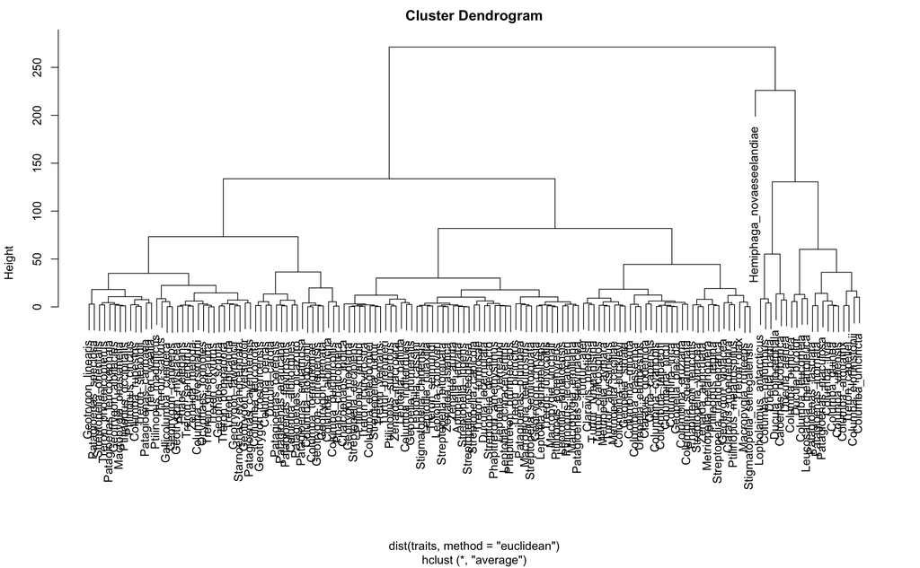

```r
analysis_all_traits = c('mass', 'locomotory_trait', 'trophic_trait')

get_traits_data_frame = function(trait_names) {
  trait_names = prepend('jetz_scientific_name', trait_names)
  traits = avonet_jetz[,trait_names]
  traits = tibble::column_to_rownames(traits, var='jetz_scientific_name')
  traits
}

get_dentrogram_for_traits = function(required_traits_for_dentro) {
  traits = get_traits_data_frame(required_traits_for_dentro)
  hclust(dist(traits,method="euclidean"), method="average")
}

dentro = get_dentrogram_for_traits(analysis_all_traits)
plot(dentro)
```

Petchey and Gaston’s FD

```r
get_fd_for_traits = function(required_traits_for_pd, communities, dentorgram = get_dentrogram_for_traits(required_traits_for_pd)) {
  result = pd(communities, as.phylo(dentorgram))
  data.frame(site = rownames(result), fd = result$PD)
}

urban_community_fd_result = get_fd_for_traits(analysis_all_traits, species_in_cities)
head(urban_community_fd_result)
```

|  | site | fd |
| --- | --- | --- |
| 1 | 514 | 157.7749 |
| 2 | 6660 | 338.0931 |
| 3 | 2054 | 403.3607 |
| 4 | 4358 | 271.2221 |
| 5 | 3079 | 336.4897 |
| 6 | 8 | 271.2221 |

```r
urban_community_fd_mass_result = get_fd_for_traits(c('locomotory_trait'), species_in_cities)
head(urban_community_fd_mass_result)
```

|  | site | fd |
| --- | --- | --- |
| 1 | 514 | 0.9480907 |
| 2 | 6660 | 1.1280245 |
| 3 | 2054 | 1.2127685 |
| 4 | 4358 | 1.0686069 |
| 5 | 3079 | 1.2082475 |
| 6 | 8 | 1.0686069 |

## Trait Variance

### FRic - Convex Hull of all traits

Using fundiversity package https://cran.r-project.org/web/packages/fundiversity/index.html Grenié M, Gruson H (2022). fundiversity: Easy Computation of Functional Diversity Indices. doi:10.5281/zenodo.4761754, R package version 1.1.1

```r
get_convex_hull = function(trait_names, communities) {
  analysis_trait_values = get_traits_data_frame(trait_names)
  fd_fric(analysis_trait_values, communities)
}

get_convex_hull(analysis_all_traits)
```

| site | FRic |
| --- | --- |
| s1 | 460.5949 |

### Single Trait Variance

How to get names of species in urban community:

```r
species_in_514 = species_in_cities[c('514'),]
species_names_in_514 = names(species_in_514)[which(species_in_514 == 1, arr.ind=T)[, "col"]]
species_names_in_514
```

```
[1] "Columbina_talpacoti" "Zenaida_auriculata"
```

How to get values of traits for species in urban community, and then var of those traits:

```r
trait_values = function(trait, community_row) {
  species_names_in_community = names(community_row)[which(community_row == 1, arr.ind=T)[, "col"]]
  traits_for_species_in_community = avonet_jetz[avonet_jetz$jetz_scientific_name %in% species_names_in_community, ]
  traits_for_species_in_community[[c(trait)]]
}

trait_values('mass', species_in_cities[c('514'),])
```

```
[1]  46.0 110.2
```

```r
var(trait_values('mass', species_in_cities[c('514'),]))
```

```
[1] 2060.82
```

Turn into a function:

```r
single_trait_variance = function(trait, communities) {
  variance_of_trait = data.frame()
  for(row in rownames(communities)) {
    community_row = communities[c(row),]
    species_names_in_community = names(community_row)[which(community_row == 1, arr.ind=T)[, "col"]]

    result = data.frame(site = row, variance = var(trait_values(trait, community_row)))
    variance_of_trait = rbind(variance_of_trait, result)
  }

  variance_of_trait
}

single_trait_variance('mass', species_in_cities)
```

| site | variance |
| --- | --- |
| 514 | 2060.8200 |
| 6660 | 10618.6133 |
| 2054 | 20053.0933 |
| 4358 | 21053.5200 |
| 3079 | 29471.6133 |
| 8 | 30603.3800 |
| 3593 | 21053.5200 |
| 2570 | 29471.6133 |
| 1291 | 9656.8492 |
| 2059 | 29471.6133 |

[output cut: 297 more lines]

## SDNDr

Standard deviation of distances between neighbouring species along a single trait axis, divided by the trait range of the community.

How to calculate SDNDr using trait values for an urban community:

```r
print('trait values:')
```

```
[1] "trait values:"
```

```r
sorted_loco_traits_in_1291 = sort(trait_values('locomotory_trait', species_in_cities[c('1291'),]))
sorted_loco_traits_in_1291
```

```
[1] -0.7063732 -0.3282555  0.2224811  0.4361998
```

```r
print('diff in neighbouring trait values:')
```

```
[1] "diff in neighbouring trait values:"
```

```r
diff(sorted_loco_traits_in_1291)
```

```
[1] 0.3781177 0.5507366 0.2137187
```

```r
print('SDNDr:')
```

```
[1] "SDNDr:"
```

```r
sd(diff(sorted_loco_traits_in_1291)) / (max(sorted_loco_traits_in_1291) - min(sorted_loco_traits_in_1291))
```

```
[1] 0.1474966
```

Turn into a function:

```r
SDNDr = function(trait, communities) {
  sdndr_of_trait = data.frame()
  for(row in rownames(communities)) {
    community_row = communities[c(row),]

    sorted_trait_values = sort(trait_values(trait, community_row))

    sdndr_value = sd(diff(sorted_trait_values)) / (max(sorted_trait_values) - min(sorted_trait_values))

    sdndr_of_trait = rbind(sdndr_of_trait, data.frame(site = row, sdndr = sdndr_value))
  }

  sdndr_of_trait
}

SDNDr('locomotory_trait', species_in_cities)
```

| site | sdndr |
| --- | --- |
| 514 | NA |
| 6660 | 0.14938876 |
| 2054 | 0.29292350 |
| 4358 | NA |
| 3079 | 0.11991869 |
| 8 | NA |
| 3593 | NA |
| 2570 | 0.11991869 |
| 1291 | 0.14749664 |
| 2059 | 0.11991869 |

[output cut: 297 more lines]

## Put it all together

```r
get_community_metrics = function(communities, included_traits = analysis_all_traits) {

  mntd_result = get_mntd_for_communities(communities)
  mpd_result = get_mpd_for_communities(communities)
  fd_all_traits = get_fd_for_traits(included_traits, communities)
  convex_hull = get_convex_hull(included_traits, communities)

  result = right_join(right_join(mntd_result, mpd_result), right_join(fd_all_traits, convex_hull))

  for (trait in included_traits) {
    col_name = function(value) {
      paste(trait, value, sep = '_')
    }

    fd_single_trait = get_fd_for_traits(trait, communities)
    var_single_trait = single_trait_variance(trait, communities)
    sdndr_single_trait = SDNDr(trait, communities)

    single_trait_result = right_join(right_join(fd_single_trait, var_single_trait), sdndr_single_trait)
    names(single_trait_result) = c('site', col_name('fd'), col_name('var'), col_name('sdndr'))
    result = right_join(result, single_trait_result)
  }

  result
}
```

```r
urban_community_values = get_community_metrics(species_in_cities)
urban_community_values
```

[output not shown]

# Calculate the null models

Our null model is every possible community of species from the regional pool with the same richness as the urban pool

Find all species in regional pool:

```r
test_city_id = 1786 # Manchester

all_columbidae_communities$jetz_scientific_name[all_columbidae_communities$city_id == test_city_id]
```

[output not shown]

Find urban richness

```r
selected_urban_communities$urban_pool_size[selected_urban_communities$city_id == test_city_id]
```

[output not shown]

Function to build every possible community

```r
create_null_model_communities = function(city_id) {
  regional_species = all_columbidae_communities$jetz_scientific_name[all_columbidae_communities$city_id == city_id]
  regional_richness = length(regional_species)
  urban_richness = selected_urban_communities$urban_pool_size[selected_urban_communities$city_id == city_id]

  null_model_sites = expand.grid(rep(list(TRUE:FALSE), regional_richness))
  null_model_sites_species_richness =  data.frame(species_richness = pmap_dbl(null_model_sites, sum))
  null_model_sites = cbind(null_model_sites, null_model_sites_species_richness)

  null_model_sites = null_model_sites[null_model_sites$species_richness == urban_richness,1:regional_richness]
  colnames(null_model_sites) = regional_species
  null_model_sites
}

create_null_model_communities(test_city_id)
```

[output not shown]

What were the results for the actual urban community in Manchester?

```r
urban_community_values[urban_community_values$site == test_city_id,]
```

[output not shown]

Test creating community metrics for our null model

```r
test_null_models = create_null_model_communities(test_city_id)

test_null_model_community_values = get_community_metrics(test_null_models)
test_null_model_community_values
```

[output not shown]

# Compare Urban Communities to regional null models

```r
normalise = function(actual_value, min_value, max_value) {
  (actual_value - min_value) / (max_value - min_value)
}

normalise(1.5, 1, 2)
```

[output not shown]

```r
standardise = function(actual_value, mean_value, sd) {
  (actual_value - mean_value) / sd
}

standardise(1.5, 1, 0.25)
```

[output not shown]

Test creating normalised and standardised FRic

```r
property = 'FRic'
actual_value = urban_community_values[urban_community_values$site == test_city_id,c(property)]
null_model_values = test_null_model_community_values[,c(property)]

print(paste('Normalised', property, 'at site', test_city_id))
normalise(actual_value, min(null_model_values), max(null_model_values))
print(paste('Standardised', property, 'at site', test_city_id))
standardise(actual_value, mean(null_model_values), sd(null_model_values))
```

[output not shown]

Create function to test actual value against all possible null model values

```r
compare_community_to_null_model = function(metric_name, actual_metric_value, null_model_metric_values) {
  min_value = min(null_model_metric_values)
  max_value = max(null_model_metric_values)
  mean_value = min(null_model_metric_values)
  sd_value = max(null_model_metric_values)

  result = data.frame(
    normalised = normalise(actual_metric_value, min_value, max_value),
    stanardised = standardise(actual_metric_value, mean_value, sd_value),
    actual = actual_metric_value,
    min = min_value,
    max = max_value,
    mean = mean_value,
    sd = sd_value
  )

  col_name = function(value) {
      paste(metric_name, value, sep = '_')
  }

  colnames(result) = c(col_name('normalised'), col_name('standardised'), col_name('actual'), col_name('min'), col_name('max'), col_name('mean'), col_name('sd'))
  result
}

compare_community_to_null_model(property, actual_value, null_model_values)
```

[output not shown]

The metrics we want to test:

```r
all_metrics_to_test = colnames(urban_community_values)[-1]
all_metrics_to_test
```

```
 [1] "mntd"                   "mpd"                    "fd"                     "FRic"                   "mass_fd"                "mass_var"               "mass_sdndr"
 [8] "locomotory_trait_fd"    "locomotory_trait_var"   "locomotory_trait_sdndr" "trophic_trait_fd"       "trophic_trait_var"      "trophic_trait_sdndr"
```

```r
create_null_model_test_values(test_city_id)
```

```
Differing number of species between trait dataset and site-species matrix
Taking subset of species
```

| city_id | mntd_normalised | mntd_standardised | mntd_actual | mntd_min | mntd_max | mntd_mean | mntd_sd | mpd_normalised | mpd_standardised | mpd_actual | mpd_min | mpd_max | mpd_mean | mpd_sd | fd_normalised | fd_standardised | fd_actual | fd_min | fd_max | fd_mean | fd_sd | FRic_normalised | FRic_standardised | FRic_actual | FRic_min | FRic_max | FRic_mean | FRic_sd | mass_fd_normalised | … |
| --- | --- | --- | --- | --- | --- | --- | --- | --- | --- | --- | --- | --- | --- | --- | --- | --- | --- | --- | --- | --- | --- | --- | --- | --- | --- | --- | --- | --- | --- | --- |
| 1786 | 1 | 0.2273598 | 19.68569 | 15.20996 | 19.68569 | 15.20996 | 19.68569 | 2.266975e-10 | 2.165222e-11 | 25.06408 | 25.06408 | 27.71078 | 25.06408 | 27.71078 | 1 | 0.1285068 | 403.3607 | 351.5261 | 403.3607 | 351.5261 | 403.3607 | 0.523872 | 0.4548924 | 0.581241 | 0.1304775 | 0.9909234 | 0.1304775 | 0.9909234 | 1 | … |

```r
urban_community_result = data.frame()

for (city_id in selected_urban_communities$city_id) {
  urban_community_result = rbind(urban_community_result, create_null_model_test_values(city_id))
}

write_csv(urban_community_result, './community_assembly_result.csv')
```

[output not shown]

[output cut: 297 more lines]